# Correction Confusion

Brian

4/24/2023

# Disclaimer

*This work is very preliminary as I get back into the coding swing of things. Data wrangling and figure generation will be done via R, but the rest of the project will be done using good ol’ microsoft products. This is just an entry point into data crunching and should by no means be considered a final product.*

*Also, I’m not great at this but whatever. I could automate this, but I’ll figure that out shortly!*

# Methodology

SNOTEL data was provided by the NRCS. Data was cleaned by removing outliers that are likely implausible; any year with more than 15 observations missing was removed. Temperatures were adjusted using the Morrisey method for stations identified by Ma et al (2019) due to SNOTEL temperature sensor changes, with the adjustment applied to pre-sensor change data. Daily mean observations were detrended to determine whether values were increasing or decreasing from the entire time series trend. Daily mean temperatures were first averaged by water year, with all water year means then averaged by day of water year. The mean temperature by day for the period of record was averaged. To find the standard deviation, the daily mean temperatures by water year was subtracted from the averaged mean temperature by day for the period of record. All water year means averaged by day of water year were subtracted from the temperature mean. The resulting values were then added together to find the “residual” of the daily mean temperatures by water year. The standard deviation was then computed from those residuals, with trends analyzed by Mann‐Kendall significance test and Theil‐Sen’s rate of change. Significant trends are identified with p-values of less than 0.10.

Morrisey Method

The Morrisey Method is taken from [Ma, Fassnacht and Kampf.](https://agupubs.onlinelibrary.wiley.com/doi/epdf/10.1029/2019WR025921).

**In the Ma et al. spreadsheet, H1 is Morrisey, H2 is Oiler**

# 4/24/2023 update

Including YSI temperature sensor bias equation from the Colorado Snow Survey, presented at the 2023 Western Snow Conference. Associated website [here.](https://www.nrcs.usda.gov/wps/portal/wcc/home/snowClimateMonitoring/temperature/temperatureBiasCorrection/)

$610558.226380138*(((T_(bias-c)+65.929))/194.45)^9- 2056177.65461394*(((T_(bias-c)+65.929))/194.45)^8+ 2937046.42906361*(((T_(bias-c)+65.929))/194.45)^7-2319657.12916417*(((T_(bias-c)+65.929))/194.45)^6+1111854.33825836*(((T_(bias-c)+65.929))/194.45)^5-337069.883250001*(((T_(bias-c)+65.929))/194.45)^4+66105.7015922199*(((T_(bias-c)+65.929))/194.45)^3- 8386.78320604513*(((T_(bias-c)+65.929))/194.45)^2+ 824.818021779729*(((T_(bias-c)+65.929))/194.45)-86.7321006757439= T_c$

# Corrections

This Rmarkdown will look at five different datasets originally collected by the Crosho SNOTEL station, as it has the largest number of usable water years’ worth of data and it was selected by Ma et al (2019) as the Morrisey correction having the largest NSCE and smallest bias. While it’s listed below, the Oyler dataset is not used in this analysis.

There are five datasets: 1) NRCS pre-sensor change data (not adjusted) 2) NRCS pre-sensor change adjusted data (Morrisey) 3) NRCS pre-sensor change adjusted data (Oyler) 4) NRCS post-sensor change adjusted data (NOAA9/CONUS) 5) NRCE pre & post sensor change adjusted data (NOAA9/CONUS over Morrisey)

### data read-in

```
SNOTEL_426 <- snotel_download(site_id = 426, path = tempdir('../data'), internal = TRUE)
write.csv(SNOTEL_426,"C:/Users/13074/Documents/ESS580/thesis_project/correction_confusion/data_raw/snotel_426.csv", row.names = FALSE) #write in the raw data
```

```r
snotel_426 <- read.csv("C:/Users/13074/Documents/ESS580/thesis_project/correction_confusion/data_raw/snotel_426.csv", header = TRUE)
```

### Crosho 426

*Morrisey* 7/21/2005

```r
#str(snotel_426) # check the date, usually a character.

snotel_426$Date <- as.Date(snotel_426$date) #change date from character to date format, capitalize to work with Water year functon from NWIS.

#THIS WILL CHANGE FOR EACH STATION
snotel_426_clean <- snotel_426 %>% # filter for the timeframe
  filter(Date >= "1979-10-01" & Date <= "2022-09-30") %>%
  #filter(temperature_mean >= -30 & temperature_mean <= 20) %>% # removing outliers
  addWaterYear() %>%
  mutate(daymonth = format(as.Date(Date), "%d-%m")) %>%
  na.omit()

#adding water day using difftime (SUPER COOL. example from [this](https://stackoverflow.com/questions/48123049/create-day-index-based-on-water-year))

snotel_426_clean <- snotel_426_clean %>%
  group_by(waterYear)%>%
  mutate(waterDay = (as.integer(difftime(Date, ymd(paste0(waterYear - 1 ,'-09-30')), units = "days"))))
```

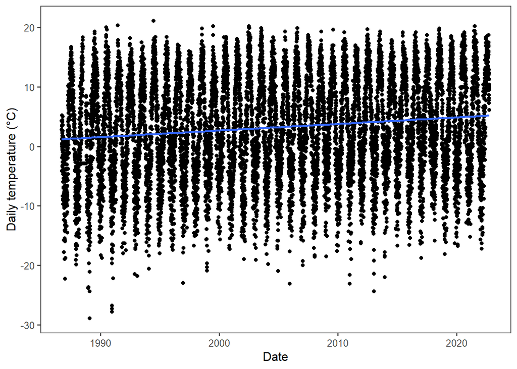

```r
# Check for outliers

ggplot(snotel_426_clean, aes(x = Date, y = temperature_mean)) +
  geom_point() + #lwd = 2) +
  theme_few() +
  geom_smooth(method = "lm", se=FALSE) +
  ylab('Daily temperature (°C)') +
  xlab('Date')
```

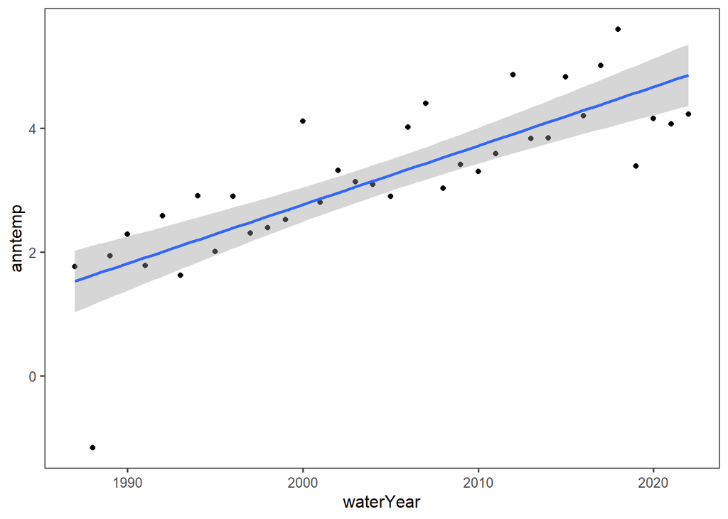

```r
# For SF average annual temp
sf <- snotel_426_clean %>%
  group_by(waterYear) %>%
  mutate(anntemp = mean(temperature_mean)) %>%
  distinct(anntemp)

ggplot(sf, aes(x=waterYear, y= anntemp))+
  geom_point()+
  geom_smooth(method = "lm", se=TRUE)+
  theme_few()
```

```r
snotel_426_clean <- snotel_426_clean %>%
  mutate(temp_diff = abs(temperature_min - temperature_max)) %>%
  filter(temperature_mean > -50) %>%
  filter(temp_diff < 40)
```

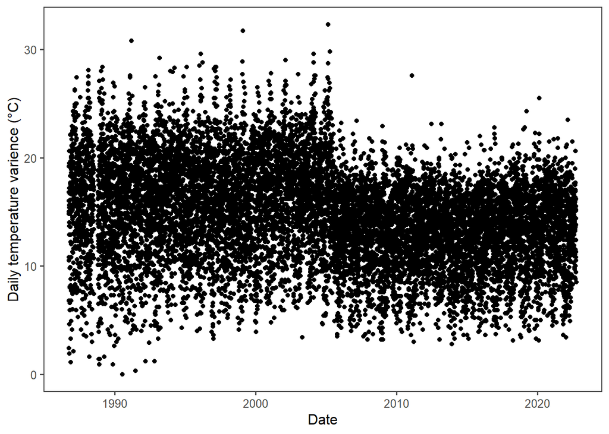

```r
ggplot(snotel_426_clean, aes(x = Date, y = temp_diff)) +
  geom_point() + #lwd = 2) +
  theme_few() +
  #geom_smooth(method = "lm", se=FALSE) +
  ylab('Daily temperature varience (°C)') +
  xlab('Date')
```

Per Steven’s advice: :If there are more than 15 missing days, then…remove that year”

```r
# filtering for temperature anomalies
#snotel_426_cull_count <- snotel_426_clean %>%
#  filter(temperature_min > -40) %>%
#  count(waterYear)

#snotel_426_cull_count

# filtering for too few observations in a year
snotel_426_cull_count_days <- snotel_426_clean %>%
  group_by(waterYear) %>%
  count(waterYear) %>%
  filter(n < 350)

snotel_426_cull_count_days
```

```
## # A tibble: 4 x 2
## # Groups:   waterYear [4]
##   waterYear     n
##       <dbl> <int>
## 1      1988   281
## 2      1989   340
## 3      2009   340
## 4      2021   349
```

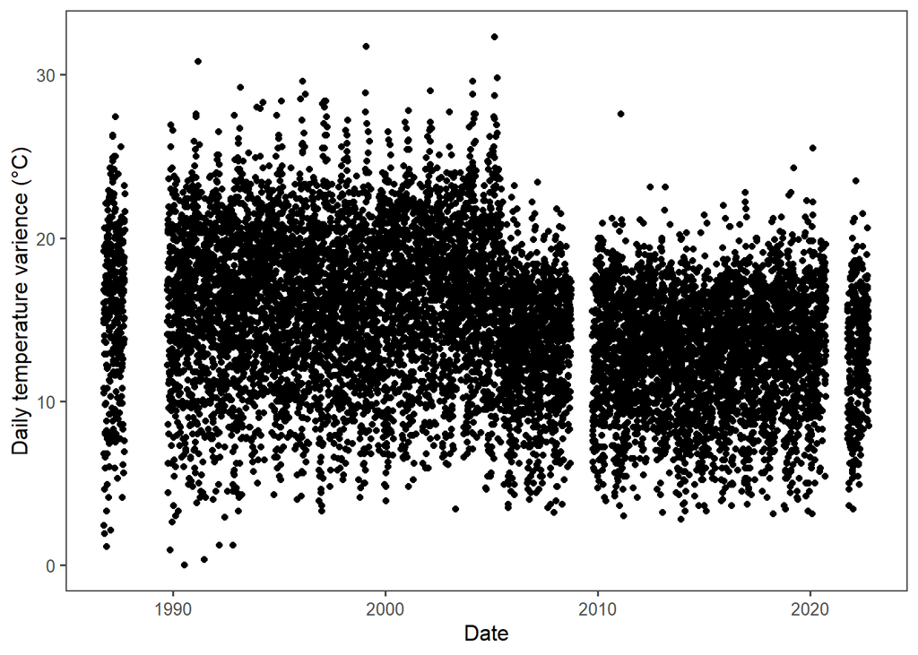

```r
snotel_426_clean_culled <- snotel_426_clean %>%
  filter(waterYear != "1988" & waterYear != "1989" & waterYear != "2009" & waterYear != "2021")# & waterYear != "2022")# & waterYear != "1986" & waterYear != "1987" & waterYear != "1994" & waterYear != "2002")# & waterYear != "2002" & waterYear != "2016" & waterYear != "2022")# & waterYear != "2017") #%>%
  #filter(temperature_mean > -49)

ggplot(snotel_426_clean_culled, aes(x = Date, y = temp_diff)) +
  geom_point() + #lwd = 2) +
  theme_few() +
  #geom_smooth(method = "lm", se=FALSE) +
  ylab('Daily temperature varience (°C)') +
  xlab('Date')
```

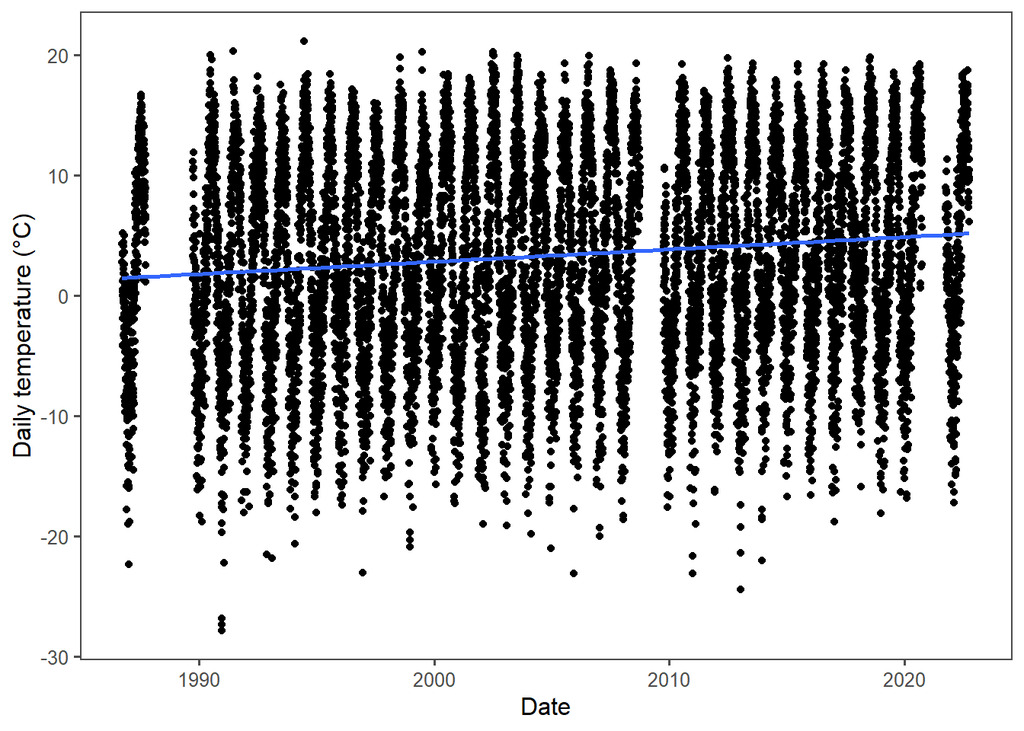

```r
ggplot(snotel_426_clean_culled, aes(x = Date, y = temperature_mean)) +
  geom_point() + #lwd = 2) +
  theme_few() +
  geom_smooth(method = "lm", se=FALSE) +
  ylab('Daily temperature (°C)') +
  xlab('Date')
```

```r
temp_426_xts <- xts(snotel_426_clean_culled$temperature_mean, order.by = snotel_426_clean_culled$Date)

dygraph(temp_426_xts) %>%
  dyAxis("y", label = "Daily mean temperature (°C)")
```

[interactive chart not shown]

```r
#snotel_426_clean_culled <- snotel_426_clean_culled %>%
#  filter(temperature_mean > -30)

#temp_426_xts <- xts(snotel_426_clean_culled$temperature_mean, order.by = snotel_426_clean_culled$Date)

#dygraph(temp_426_xts) %>%
#  dyAxis("y", label = "Daily mean temperature (°C)")
```

### adjusted

Crosho 426 *Morrisey* 7/21/2005

Need four datasets:

1. NRCS pre-sensor change data (not adjusted) *“temperature_mean”*
2. NRCS pre-sensor change adjusted data (Morrisey) *“morrisey”*
3. NRCS post-sensor change adjusted data (NOAA9/CONUS) *“noaa_conus”*
4. NRCE pre & post sensor change adjusted data (NOAA9/CONUS over Morrisey) *“noaa_morrisey”*

```r
# 2) NRCS pre-sensor change adjusted data (Morrisey) *"morrisey"*

snotel_426_adjusted <- snotel_426_clean_culled %>%
  mutate(morrisey = if_else(Date < "2005-07-21", ((5.3*10^(-7))*(temperature_mean^(4))+(3.72*10^(-5))*(temperature_mean^(3))-(2.16*10^(-3))*(temperature_mean^(2))-(7.32*10^(-2))*(temperature_mean)+1.37)+temperature_mean, temperature_mean)) %>%
  mutate(noaa_conus = if_else(Date >= "2005-07-21", 610558.226380138*(((temperature_mean+65.929))/194.45)^9-2056177.65461394*(((temperature_mean+65.929))/194.45)^8+2937046.42906361*(((temperature_mean+65.929))/194.45)^7-2319657.12916417*(((temperature_mean+65.929))/194.45)^6+1111854.33825836*(((temperature_mean+65.929))/194.45)^5-337069.883250001*(((temperature_mean+65.929))/194.45)^4+66105.7015922199*(((temperature_mean+65.929))/194.45)^3- 8386.78320604513*(((temperature_mean+65.929))/194.45)^2+ 824.818021779729*(((temperature_mean+65.929))/194.45)-86.7321006757439, temperature_mean)) %>%
  mutate(noaa_morrisey = 610558.226380138*(((morrisey+65.929))/194.45)^9-2056177.65461394*(((morrisey+65.929))/194.45)^8+2937046.42906361*(((morrisey+65.929))/194.45)^7-2319657.12916417*(((morrisey+65.929))/194.45)^6+1111854.33825836*(((morrisey+65.929))/194.45)^5-337069.883250001*(((morrisey+65.929))/194.45)^4+66105.7015922199*(((morrisey+65.929))/194.45)^3- 8386.78320604513*(((morrisey+65.929))/194.45)^2+ 824.818021779729*(((morrisey+65.929))/194.45)-86.7321006757439)
```

# mean temperatures w/ corrections:

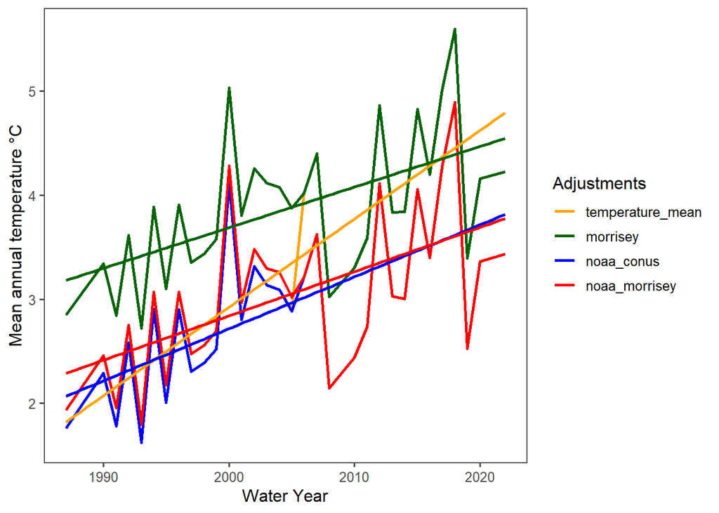

Annual temperature by correction.

```r
all_annual_temp_adjustments <- snotel_426_adjusted %>%
  group_by(waterYear) %>%
  mutate(mean_temp_mean = mean(temperature_mean)) %>%
  mutate(mean_morri = mean(morrisey)) %>%
  mutate(mean_noaa_con = mean(noaa_conus)) %>%
  mutate(mean_noaa_morr = mean(noaa_morrisey)) %>%
  distinct(waterYear, .keep_all = TRUE)

ggplot(all_annual_temp_adjustments, aes(x=waterYear)) +
  geom_line(aes(y = mean_temp_mean, color = "temperature_mean"), size =1)+
  geom_line(aes(y = mean_morri, color = "morrisey"), size =1)+
  geom_line(aes(y = mean_noaa_con, color = "noaa_conus"), size =1)+
  geom_line(aes(y = mean_noaa_morr, color= "noaa_morrisey"), size =1)+
  geom_smooth(aes(x=waterYear, y = mean_temp_mean, color = "temperature_mean"), method=lm, se=FALSE)+
  geom_smooth(aes(x=waterYear, y = mean_morri, color = "morrisey"), method=lm, se=FALSE)+
  geom_smooth(aes(x=waterYear, y = mean_noaa_con, color = "noaa_conus"), method=lm, se=FALSE)+
  geom_smooth(aes(x=waterYear, y = mean_noaa_morr, color= "noaa_morrisey"), method=lm, se=FALSE)+

  theme_few()+
  scale_colour_manual(name = "Adjustments", values=c("temperature_mean"="orange", "morrisey" = "darkgreen", "noaa_conus" ="blue", "noaa_morrisey" = "red"))+
  xlab("Water Year")+
  ylab("Mean annual temperature °C")
```

# 1:1

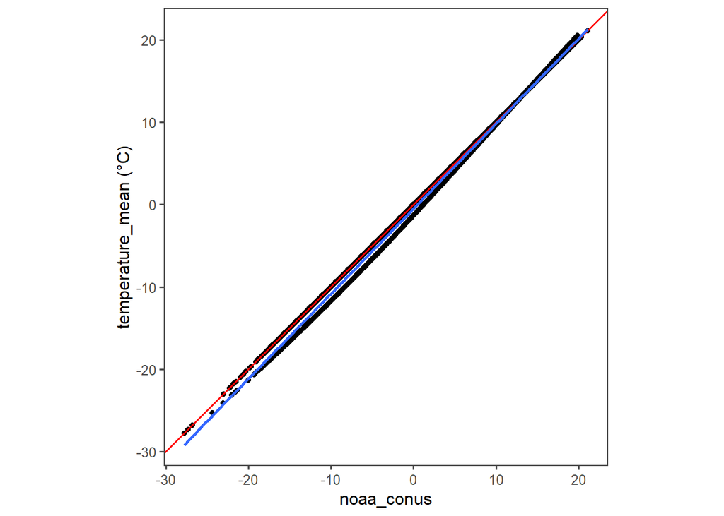

Mean daily temperature vs. NOAA-CONUS bias correction.

```r
ggplot(snotel_426_adjusted, aes(x = temperature_mean, y = noaa_conus)) +
  geom_point() +
  theme_few() +
  coord_equal() +
  geom_abline(slope=1, intercept=0, color= "red", size = 0.7) +
  geom_smooth(method = "lm", se=FALSE) +
  ylab('temperature_mean (°C)') +
  xlab('noaa_conus')
```

```r
snotel_426_adjusted
```

```
## # A tibble: 11,618 x 26
## # Groups:   waterYear [32]
##    network state site_name description      start end   latitude longitude  elev
##    <chr>   <chr> <chr>     <chr>            <chr> <chr>    <dbl>     <dbl> <int>
##  1 SNTL    CO    "crosho " Outlet Hunt Cre~ 1985~ 2023~     40.2     -107.  2735
##  2 SNTL    CO    "crosho " Outlet Hunt Cre~ 1985~ 2023~     40.2     -107.  2735
##  3 SNTL    CO    "crosho " Outlet Hunt Cre~ 1985~ 2023~     40.2     -107.  2735
##  4 SNTL    CO    "crosho " Outlet Hunt Cre~ 1985~ 2023~     40.2     -107.  2735
##  5 SNTL    CO    "crosho " Outlet Hunt Cre~ 1985~ 2023~     40.2     -107.  2735
##  6 SNTL    CO    "crosho " Outlet Hunt Cre~ 1985~ 2023~     40.2     -107.  2735
##  7 SNTL    CO    "crosho " Outlet Hunt Cre~ 1985~ 2023~     40.2     -107.  2735
##  8 SNTL    CO    "crosho " Outlet Hunt Cre~ 1985~ 2023~     40.2     -107.  2735
##  9 SNTL    CO    "crosho " Outlet Hunt Cre~ 1985~ 2023~     40.2     -107.  2735
## 10 SNTL    CO    "crosho " Outlet Hunt Cre~ 1985~ 2023~     40.2     -107.  2735
## # ... with 11,608 more rows, and 17 more variables: county <chr>,
## #   site_id <int>, date <chr>, snow_water_equivalent <dbl>,
## #   precipitation_cumulative <dbl>, temperature_max <dbl>,
## #   temperature_min <dbl>, temperature_mean <dbl>, precipitation <dbl>,
## #   Date <date>, waterYear <dbl>, daymonth <chr>, waterDay <int>,
## #   temp_diff <dbl>, morrisey <dbl>, noaa_conus <dbl>, noaa_morrisey <dbl>
```

```r
write.csv(snotel_426_adjusted,"C:/Users/13074/Documents/ESS580/thesis_project/correction_confusion/data_clean/snotel_426_adjusted.csv", row.names = FALSE)
```

#### 426 Detrended for temperature_mean

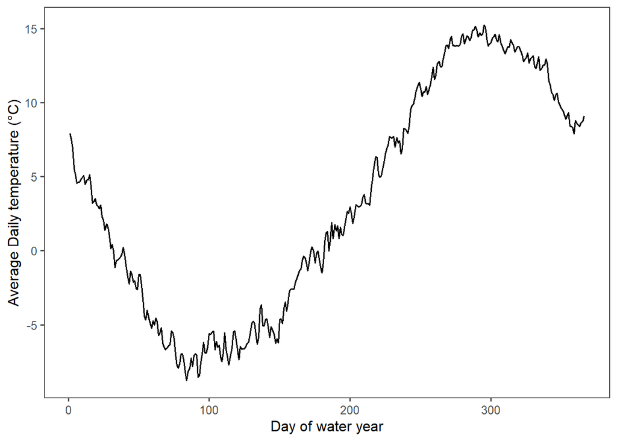

```r
#average water year temperature
yearly_wy_aver_426 <- snotel_426_adjusted %>%
  group_by(waterYear) %>%
  mutate(aver_ann_temp = mean(temperature_mean))
#Average temperature by day for all water years:
daily_wy_aver_426 <- yearly_wy_aver_426 %>%
  group_by(daymonth) %>%
  mutate(aver_day_temp = mean(temperature_mean))
#average mean temperature by day for the period of record:
daily_wy_aver_426 <- daily_wy_aver_426 %>%
  group_by(daymonth) %>%
  mutate(all_ave_temp = mean(daily_wy_aver_426$aver_day_temp))
# try to show all years as means.
daily_wy_aver2_426 <-daily_wy_aver_426 %>%
  group_by(waterDay) %>%
  mutate(date_temp = mean(temperature_mean))

daily_wy_aver2_426$date_temp <- (daily_wy_aver2_426$date_temp) #reduce the sig figs
ggplot(daily_wy_aver2_426, aes(x = waterDay, y = date_temp))+
  geom_line(size= 0.7) +
  theme_few() +
  ylab('Average Daily temperature (°C)') +
  xlab('Day of water year')
```

#### 426 temperature_mean SD

```r
standard_dev_426 <- daily_wy_aver_426 %>%
  group_by(waterYear) %>%
  mutate(residual = (all_ave_temp-aver_ann_temp)+temperature_mean-aver_day_temp) %>%
  mutate(deviation = abs(residual-lag(residual)))
standard_dev_all_426 <- standard_dev_426 %>%
  group_by(waterYear) %>%
  mutate(nmbr = n())
standard_dev_all_426 <- standard_dev_all_426 %>%
  group_by(waterYear) %>%
  mutate(resid_mean = mean(residual)) %>%
  mutate(sd_1 = residual-resid_mean) %>%
  mutate(sd_2 = (((sum((sd_1)^2))/((nmbr-1))))^(0.5)) %>%
  distinct(sd_2, .keep_all = TRUE) %>%
   select(waterYear, sd_2)
standard_dev_all_426 %>%
  kable(.,'html') %>%
  kable_styling() %>%
  scroll_box(width='250px',height='500px')
```

| waterYear | sd_2 |
| --- | --- |
| 1987 | 3.834819 |
| 1990 | 3.918121 |
| 1991 | 4.193319 |
| 1992 | 3.881500 |
| 1993 | 3.886407 |
| 1994 | 3.902186 |
| 1995 | 4.041780 |
| 1996 | 4.038602 |
| 1997 | 4.109471 |
| 1998 | 3.674869 |
| 1999 | 4.067740 |
| 2000 | 3.837752 |
| 2001 | 3.834053 |
| 2002 | 4.155117 |
| 2003 | 3.908081 |
| 2004 | 4.121505 |
| 2005 | 3.658336 |
| 2006 | 4.094499 |
| 2007 | 3.932166 |
| 2008 | 3.896578 |
| 2010 | 3.812591 |
| 2011 | 3.847931 |
| 2012 | 3.616149 |
| 2013 | 4.095075 |
| 2014 | 3.902875 |
| 2015 | 3.929717 |
| 2016 | 3.666997 |
| 2017 | 4.362533 |
| 2018 | 3.757619 |
| 2019 | 3.744243 |
| 2020 | 4.092586 |
| 2022 | 4.104998 |

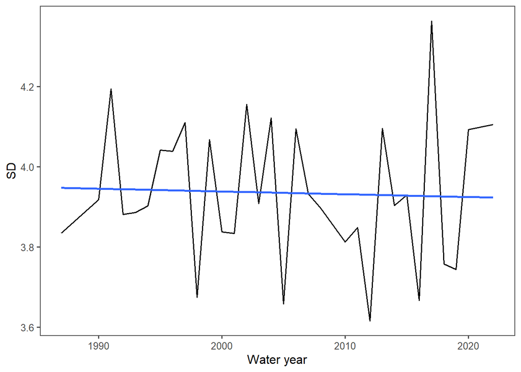

```r
ggplot(standard_dev_all_426, aes(x = waterYear, y = sd_2))+
  geom_line(size= 0.7) +
  theme_few() +
  geom_smooth(method = "lm", se=FALSE) +
  ylab('SD') +
  xlab('Water year')
```

#### MK & SS for 426 (non-corrected)

```r
sd_mk_426 <- mk.test(standard_dev_all_426$sd_2)
print(sd_mk_426)
```

```
##
##  Mann-Kendall trend test
##
## data:  standard_dev_all_426$sd_2
## z = -0.27568, n = 32, p-value = 0.7828
## alternative hypothesis: true S is not equal to 0
## sample estimates:
##             S          varS           tau
##  -18.00000000 3802.66666667   -0.03629032
```

```r
sd_sens_426 <- sens.slope(standard_dev_all_426$sd_2)
print(sd_sens_426)
```

```
##
##  Sen's slope
##
## data:  standard_dev_all_426$sd_2
## z = -0.27568, n = 32, p-value = 0.7828
## alternative hypothesis: true z is not equal to 0
## 95 percent confidence interval:
##  -0.007716966  0.006021334
## sample estimates:
##   Sen's slope
## -0.0007151733
```

#### 426 Morrisey corrected

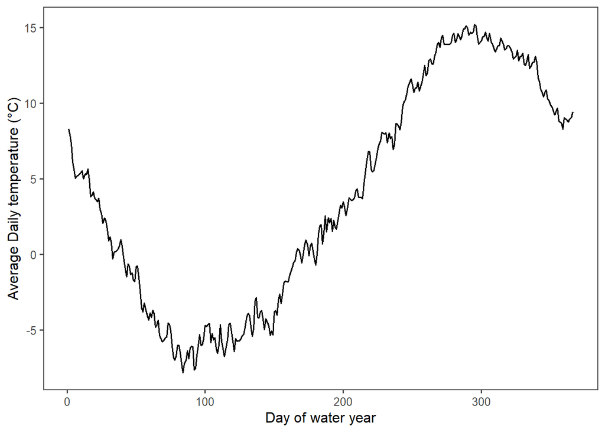

```r
#using the clean culled df:
#average water year temperature
yearly_wy_aver_426_morrisey <- snotel_426_adjusted %>%
  group_by(waterYear) %>%
  mutate(aver_ann_temp_morrisey = mean(morrisey))
#Average temperature by day for all water years:
daily_wy_aver_426_morrisey <- yearly_wy_aver_426_morrisey %>%
  group_by(daymonth) %>%
  mutate(aver_day_temp_morrisey = mean(morrisey))
#average mean temperature by day for the period of record:
daily_wy_aver_426_morrisey <- daily_wy_aver_426_morrisey %>%
  group_by(daymonth) %>%
  mutate(all_ave_temp_morrisey = mean(daily_wy_aver_426_morrisey$aver_day_temp_morrisey))
# try to show all years as means.
daily_wy_aver2_426_morrisey <-daily_wy_aver_426_morrisey %>%
  group_by(waterDay) %>%
  mutate(date_temp_morrisey = mean(morrisey))

daily_wy_aver2_426_morrisey$date_temp_morrisey <- signif(daily_wy_aver2_426_morrisey$date_temp_morrisey,3) #reduce the sig figs
ggplot(daily_wy_aver2_426_morrisey, aes(x = waterDay, y = date_temp_morrisey))+
  geom_line(size= 0.7) +
  theme_few() +
  ylab('Average Daily temperature (°C)') +
  xlab('Day of water year')
```

#### 426 SS (Morrisey corrected)

```r
standard_dev_426_morrisey <- daily_wy_aver_426_morrisey %>%
  group_by(waterYear) %>%
  #filter(waterYear >= 1987 & waterYear <= 2021) %>%
  mutate(residual = (all_ave_temp_morrisey-aver_ann_temp_morrisey)+morrisey-aver_day_temp_morrisey) %>%
  mutate(deviation = abs(residual-lag(residual)))
standard_dev_all_426_morrisey <- standard_dev_426_morrisey %>%
  group_by(waterYear) %>%
  mutate(nmbr = n())
standard_dev_all_426_morrisey <- standard_dev_all_426_morrisey %>%
  group_by(waterYear) %>%
  mutate(resid_mean = mean(residual)) %>%
  mutate(sd_1 = residual-resid_mean) %>%
  mutate(sd_2 = (((sum((sd_1)^2))/((nmbr-1))))^(0.5)) %>%
  distinct(sd_2, .keep_all = TRUE) %>%
   select(waterYear, sd_2)
standard_dev_all_426_morrisey %>%
  kable(.,'html') %>%
  kable_styling() %>%
  scroll_box(width='250px',height='500px')
```

| waterYear | sd_2 |
| --- | --- |
| 1987 | 3.627709 |
| 1990 | 3.674185 |
| 1991 | 3.997144 |
| 1992 | 3.649277 |
| 1993 | 3.684324 |
| 1994 | 3.618291 |
| 1995 | 3.826261 |
| 1996 | 3.807886 |
| 1997 | 3.888079 |
| 1998 | 3.427325 |
| 1999 | 3.894831 |
| 2000 | 3.601963 |
| 2001 | 3.560656 |
| 2002 | 3.823950 |
| 2003 | 3.629810 |
| 2004 | 3.875988 |
| 2005 | 3.503987 |
| 2006 | 4.092093 |
| 2007 | 3.964001 |
| 2008 | 3.921936 |
| 2010 | 3.848989 |
| 2011 | 3.837802 |
| 2012 | 3.625870 |
| 2013 | 4.125630 |
| 2014 | 3.864103 |
| 2015 | 3.851285 |
| 2016 | 3.663402 |
| 2017 | 4.310831 |
| 2018 | 3.731610 |
| 2019 | 3.769766 |
| 2020 | 4.127815 |
| 2022 | 4.090745 |

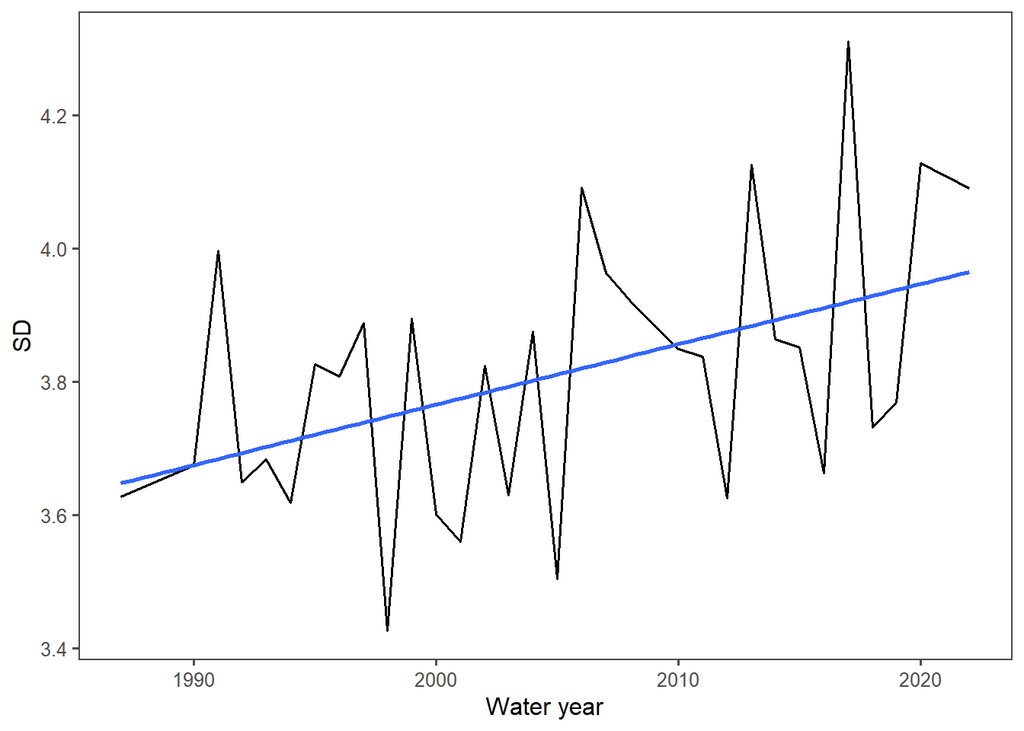

```r
ggplot(standard_dev_all_426_morrisey, aes(x = waterYear, y = sd_2))+
  geom_line(size= 0.7) +
  theme_few() +
  geom_smooth(method = "lm", se=FALSE) +
  ylab('SD') +
  xlab('Water year')
```

#### MK & SS 426 (Morrisey corrected)

```r
sd_mk_426_morrisey <- mk.test(standard_dev_all_426_morrisey$sd_2)
print(sd_mk_426_morrisey)
```

```
##
##  Mann-Kendall trend test
##
## data:  standard_dev_all_426_morrisey$sd_2
## z = 2.1244, n = 32, p-value = 0.03364
## alternative hypothesis: true S is not equal to 0
## sample estimates:
##           S        varS         tau
##  132.000000 3802.666667    0.266129
```

```r
sd_sens_426_morrisey <- sens.slope(standard_dev_all_426_morrisey$sd_2)
print(sd_sens_426_morrisey)
```

```
##
##  Sen's slope
##
## data:  standard_dev_all_426_morrisey$sd_2
## z = 2.1244, n = 32, p-value = 0.03364
## alternative hypothesis: true z is not equal to 0
## 95 percent confidence interval:
##  0.000769358 0.017057352
## sample estimates:
## Sen's slope
##   0.0091912
```

#### 426 noaa_conus

#### 426 noaa_conus corrected

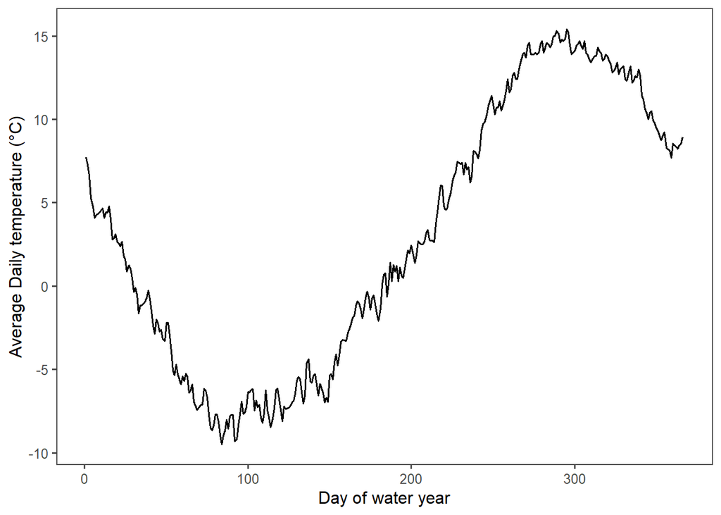

```r
#using the clean culled df:
#average water year temperature
yearly_wy_aver_426_noaa_conus <- snotel_426_adjusted %>%
  group_by(waterYear) %>%
  mutate(aver_ann_temp_noaa_conus = mean(noaa_conus))
#Average temperature by day for all water years:
daily_wy_aver_426_noaa_conus <- yearly_wy_aver_426_noaa_conus %>%
  group_by(daymonth) %>%
  mutate(aver_day_temp_noaa_conus = mean(noaa_conus))
#average mean temperature by day for the period of record:
daily_wy_aver_426_noaa_conus <- daily_wy_aver_426_noaa_conus %>%
  group_by(daymonth) %>%
  mutate(all_ave_temp_noaa_conus = mean(daily_wy_aver_426_noaa_conus$aver_day_temp_noaa_conus))
# try to show all years as means.
daily_wy_aver2_426_noaa_conus <-daily_wy_aver_426_noaa_conus %>%
  group_by(waterDay) %>%
  mutate(date_temp_noaa_conus = mean(noaa_conus))

daily_wy_aver2_426_noaa_conus$date_temp_noaa_conus <- signif(daily_wy_aver2_426_noaa_conus$date_temp_noaa_conus,3) #reduce the sig figs
ggplot(daily_wy_aver2_426_noaa_conus, aes(x = waterDay, y = date_temp_noaa_conus))+
  geom_line(size= 0.7) +
  theme_few() +
  ylab('Average Daily temperature (°C)') +
  xlab('Day of water year')
```

#### 426 SS (noaa_conus corrected)

```r
standard_dev_426_noaa_conus <- daily_wy_aver_426_noaa_conus %>%
  group_by(waterYear) %>%
  #filter(waterYear >= 1987 & waterYear <= 2021) %>%
  mutate(residual = (all_ave_temp_noaa_conus-aver_ann_temp_noaa_conus)+noaa_conus-aver_day_temp_noaa_conus) %>%
  mutate(deviation = abs(residual-lag(residual)))
standard_dev_all_426_noaa_conus <- standard_dev_426_noaa_conus %>%
  group_by(waterYear) %>%
  mutate(nmbr = n())
standard_dev_all_426_noaa_conus <- standard_dev_all_426_noaa_conus %>%
  group_by(waterYear) %>%
  mutate(resid_mean = mean(residual)) %>%
  mutate(sd_1 = residual-resid_mean) %>%
  mutate(sd_2 = (((sum((sd_1)^2))/((nmbr-1))))^(0.5)) %>%
  distinct(sd_2, .keep_all = TRUE) %>%
   select(waterYear, sd_2)
standard_dev_all_426_noaa_conus %>%
  kable(.,'html') %>%
  kable_styling() %>%
  scroll_box(width='250px',height='500px')
```

| waterYear | sd_2 |
| --- | --- |
| 1987 | 3.845969 |
| 1990 | 3.923457 |
| 1991 | 4.180041 |
| 1992 | 3.911344 |
| 1993 | 3.897471 |
| 1994 | 3.834816 |
| 1995 | 4.089090 |
| 1996 | 4.057944 |
| 1997 | 4.127080 |
| 1998 | 3.660302 |
| 1999 | 4.139907 |
| 2000 | 3.870950 |
| 2001 | 3.796450 |
| 2002 | 4.076662 |
| 2003 | 3.888072 |
| 2004 | 4.159076 |
| 2005 | 3.730562 |
| 2006 | 4.346297 |
| 2007 | 4.200806 |
| 2008 | 4.164044 |
| 2010 | 4.106267 |
| 2011 | 4.035321 |
| 2012 | 3.894366 |
| 2013 | 4.340183 |
| 2014 | 4.097495 |
| 2015 | 4.110710 |
| 2016 | 3.903394 |
| 2017 | 4.604005 |
| 2018 | 4.008092 |
| 2019 | 4.008400 |
| 2020 | 4.397441 |
| 2022 | 4.345973 |

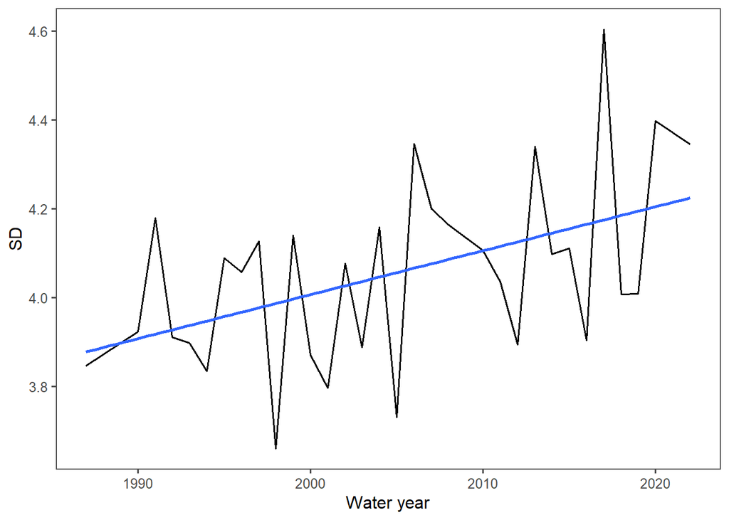

```r
ggplot(standard_dev_all_426_noaa_conus, aes(x = waterYear, y = sd_2))+
  geom_line(size= 0.7) +
  theme_few() +
  geom_smooth(method = "lm", se=FALSE) +
  ylab('SD') +
  xlab('Water year')
```

#### MK & SS 426 (noaa_conus corrected)

```r
sd_mk_426_noaa_conus <- mk.test(standard_dev_all_426_noaa_conus$sd_2)
print(sd_mk_426_noaa_conus)
```

```
##
##  Mann-Kendall trend test
##
## data:  standard_dev_all_426_noaa_conus$sd_2
## z = 2.1892, n = 32, p-value = 0.02858
## alternative hypothesis: true S is not equal to 0
## sample estimates:
##            S         varS          tau
##  136.0000000 3802.6666667    0.2741935
```

```r
sd_sens_426_noaa_conus <- sens.slope(standard_dev_all_426_noaa_conus$sd_2)
print(sd_sens_426_noaa_conus)
```

```
##
##  Sen's slope
##
## data:  standard_dev_all_426_noaa_conus$sd_2
## z = 2.1892, n = 32, p-value = 0.02858
## alternative hypothesis: true z is not equal to 0
## 95 percent confidence interval:
##  0.001226952 0.017426598
## sample estimates:
## Sen's slope
## 0.009185885
```

#### 426 noaa_morrisey

#### 426 noaa_morrisey corrected

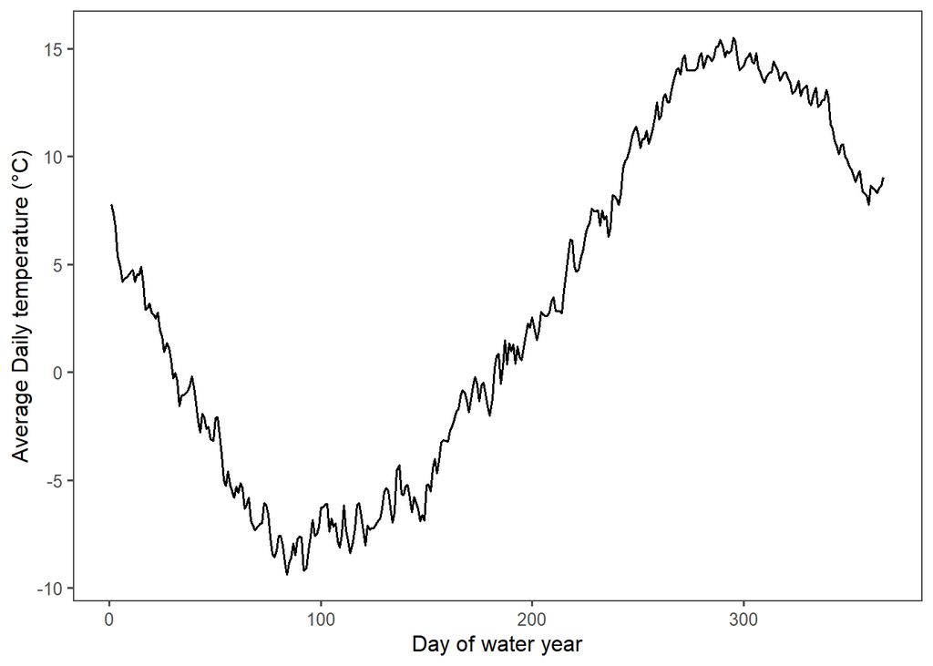

```r
#using the clean culled df:
#average water year temperature
yearly_wy_aver_426_noaa_morrisey <- snotel_426_adjusted %>%
  group_by(waterYear) %>%
  mutate(aver_ann_temp_noaa_morrisey = mean(noaa_morrisey))
#Average temperature by day for all water years:
daily_wy_aver_426_noaa_morrisey <- yearly_wy_aver_426_noaa_morrisey %>%
  group_by(daymonth) %>%
  mutate(aver_day_temp_noaa_morrisey = mean(noaa_morrisey))
#average mean temperature by day for the period of record:
daily_wy_aver_426_noaa_morrisey <- daily_wy_aver_426_noaa_morrisey %>%
  group_by(daymonth) %>%
  mutate(all_ave_temp_noaa_morrisey = mean(daily_wy_aver_426_noaa_morrisey$aver_day_temp_noaa_morrisey))
# try to show all years as means.
daily_wy_aver2_426_noaa_morrisey <-daily_wy_aver_426_noaa_morrisey %>%
  group_by(waterDay) %>%
  mutate(date_temp_noaa_morrisey = mean(noaa_morrisey))

daily_wy_aver2_426_noaa_morrisey$date_temp_noaa_morrisey <- signif(daily_wy_aver2_426_noaa_morrisey$date_temp_noaa_morrisey,3) #reduce the sig figs
ggplot(daily_wy_aver2_426_noaa_morrisey, aes(x = waterDay, y = date_temp_noaa_morrisey))+
  geom_line(size= 0.7) +
  theme_few() +
  ylab('Average Daily temperature (°C)') +
  xlab('Day of water year')
```

#### 426 SS (noaa_morrisey corrected)

```r
standard_dev_426_noaa_morrisey <- daily_wy_aver_426_noaa_morrisey %>%
  group_by(waterYear) %>%
  #filter(waterYear >= 1987 & waterYear <= 2021) %>%
  mutate(residual = (all_ave_temp_noaa_morrisey-aver_ann_temp_noaa_morrisey)+noaa_morrisey-aver_day_temp_noaa_morrisey) %>%
  mutate(deviation = abs(residual-lag(residual)))
standard_dev_all_426_noaa_morrisey <- standard_dev_426_noaa_morrisey %>%
  group_by(waterYear) %>%
  mutate(nmbr = n())
standard_dev_all_426_noaa_morrisey <- standard_dev_all_426_noaa_morrisey %>%
  group_by(waterYear) %>%
  mutate(resid_mean = mean(residual)) %>%
  mutate(sd_1 = residual-resid_mean) %>%
  mutate(sd_2 = (((sum((sd_1)^2))/((nmbr-1))))^(0.5)) %>%
  distinct(sd_2, .keep_all = TRUE) %>%
   select(waterYear, sd_2)
standard_dev_all_426_noaa_morrisey %>%
  kable(.,'html') %>%
  kable_styling() %>%
  scroll_box(width='250px',height='500px')
```

| waterYear | sd_2 |
| --- | --- |
| 1987 | 3.839078 |
| 1990 | 3.915802 |
| 1991 | 4.161676 |
| 1992 | 3.904904 |
| 1993 | 3.886897 |
| 1994 | 3.825685 |
| 1995 | 4.083507 |
| 1996 | 4.057619 |
| 1997 | 4.124626 |
| 1998 | 3.656669 |
| 1999 | 4.136319 |
| 2000 | 3.871302 |
| 2001 | 3.789954 |
| 2002 | 4.065007 |
| 2003 | 3.880269 |
| 2004 | 4.154063 |
| 2005 | 3.726061 |
| 2006 | 4.344997 |
| 2007 | 4.201866 |
| 2008 | 4.164556 |
| 2010 | 4.106236 |
| 2011 | 4.035718 |
| 2012 | 3.893362 |
| 2013 | 4.339690 |
| 2014 | 4.097499 |
| 2015 | 4.111111 |
| 2016 | 3.902955 |
| 2017 | 4.604205 |
| 2018 | 4.008204 |
| 2019 | 4.008858 |
| 2020 | 4.397548 |
| 2022 | 4.345734 |

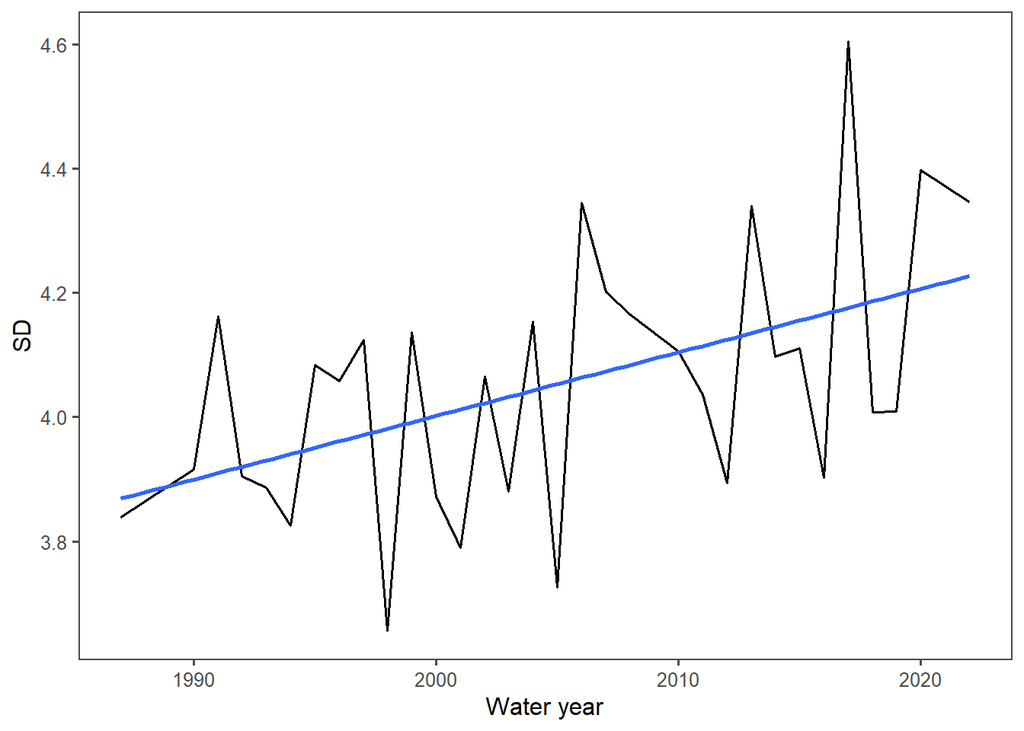

```r
ggplot(standard_dev_all_426_noaa_morrisey, aes(x = waterYear, y = sd_2))+
  geom_line(size= 0.7) +
  theme_few() +
  geom_smooth(method = "lm", se=FALSE) +
  ylab('SD') +
  xlab('Water year')
```

#### MK & SS 426 (noaa_morrisey corrected)

```r
sd_mk_426_noaa_morrisey <- mk.test(standard_dev_all_426_noaa_morrisey$sd_2)
print(sd_mk_426_noaa_morrisey)
```

```
##
##  Mann-Kendall trend test
##
## data:  standard_dev_all_426_noaa_morrisey$sd_2
## z = 2.2865, n = 32, p-value = 0.02222
## alternative hypothesis: true S is not equal to 0
## sample estimates:
##            S         varS          tau
##  142.0000000 3802.6666667    0.2862903
```

```r
sd_sens_426_noaa_morrisey <- sens.slope(standard_dev_all_426_noaa_morrisey$sd_2)
print(sd_sens_426_noaa_morrisey)
```

```
##
##  Sen's slope
##
## data:  standard_dev_all_426_noaa_morrisey$sd_2
## z = 2.2865, n = 32, p-value = 0.02222
## alternative hypothesis: true z is not equal to 0
## 95 percent confidence interval:
##  0.001623565 0.017629381
## sample estimates:
## Sen's slope
## 0.009493217
```

# Figure SD all together

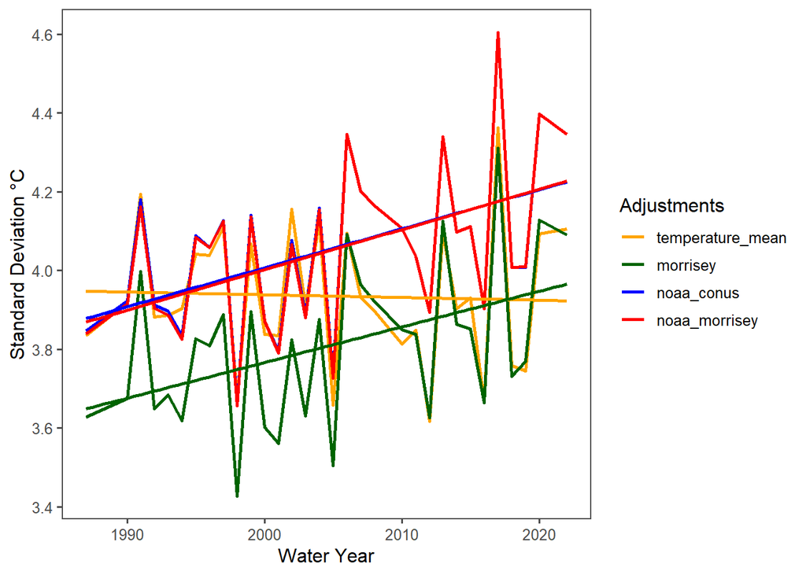

Standard deviation for different corrections.

```r
all_adjustments <- standard_dev_all_426_noaa_morrisey %>%
  inner_join(standard_dev_all_426_noaa_conus, by= 'waterYear') %>%
  left_join(standard_dev_all_426_morrisey, by= 'waterYear') %>%
  left_join(standard_dev_all_426, by= 'waterYear') %>%
  rename(noaa_morrisey = sd_2.x) %>%
  rename(noaa_conus = sd_2.y) %>%
  rename(morrisey = sd_2.x.x) %>%
  rename(temperature_mean = sd_2.y.y)




ggplot(all_adjustments, aes(x=waterYear)) +
         #scale_size_manual(values=c("FALSE"=5,"TRUE"=8)) +
  #scale_color_manual(values=c("FALSE"='#CC0000',"TRUE"='black')) +
geom_line(aes(y = temperature_mean, color = "temperature_mean"), size =1)+
  geom_line(aes(y = morrisey, color = "morrisey"), size =1)+
  geom_line(aes(y = noaa_conus, color = "noaa_conus"), size =1)+
  geom_line(aes(y = noaa_morrisey, color= "noaa_morrisey"), size =1)+
  geom_smooth(aes(x=waterYear, y = temperature_mean, color = "temperature_mean"), method=lm, se=FALSE)+
  geom_smooth(aes(x=waterYear, y = morrisey, color = "morrisey"), method=lm, se=FALSE)+
  geom_smooth(aes(x=waterYear, y = noaa_conus, color = "noaa_conus"), method=lm, se=FALSE)+
  geom_smooth(aes(x=waterYear, y = noaa_morrisey, color= "noaa_morrisey"), method=lm, se=FALSE)+

  theme_few()+
  scale_colour_manual(name = "Adjustments", values=c("temperature_mean"="orange", "morrisey" = "darkgreen", "noaa_conus" ="blue", "noaa_morrisey" = "red"))+
  xlab("Water Year")+
  ylab("Standard Deviation °C")
```

```r
# breaks=c("date_temp.x","date_temp.y","date_temp.x.x", "date_temp.y.y"),
```

Question: Why doesn’t Morrisey directly follow the mean temperature? *The detrending process uses the mean of the period of record as well as the mean day-of-water year temperature, both of which affect the standard deviation for each water year. Applying a bias correction will change the mean of the period of record and the mean day-of-water year temperature, so even if the mean temperature values are the same after the temperature sensor change there will still be some difference between the annual standard deviation values.*

# Adding in Oyler data

Using geoknife, I was able to download Oyler TopoWx data for comparison to the other datasets. It’s specified above as “3) NRCS pre-sensor change adjusted data (Oyler).” Since Oyler used the YSI extended range sensors to correlate temperature at the SNOTEL stations, it seems likely that applying the NOAA_CONUS bias correction is necessary as well. The data were imported into a different .rmd, with the SNOTEL data water years removed (1988, 1989, 2009, 2021). Since the Oyler data only extends to 2016, the figures below will reflect the shortened Oyler and Oyler-NOAA-CONUS corrected time series.

```r
Oyler_annual_temp_adjustments <- read.csv("C:/Users/13074/Documents/ESS580/thesis_project/correction_confusion/data_clean/Oyler_annual_temp_adjustments.csv", header = TRUE)

Oyler_SD <- read.csv("C:/Users/13074/Documents/ESS580/thesis_project/correction_confusion/data_clean/Oyler_standard_dev_all_426.csv", header = TRUE)

Oyler_SD_NOAA_CONUS <- read.csv("C:/Users/13074/Documents/ESS580/thesis_project/correction_confusion/data_clean/Oyler_standard_dev_all_426_noaa_conus.csv", header = TRUE)
```

# All datasets mean temperature

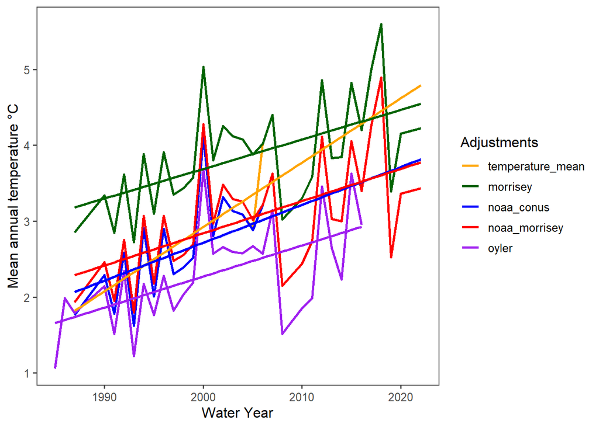

Mean annual temperature by correction.

```r
Oyler_mean <- Oyler_annual_temp_adjustments %>%
  select(waterYear, mean_temp_mean, mean_noaa_con)

all_annual_temp_adjustments_Oyler <- all_annual_temp_adjustments %>%
  select(waterYear, mean_temp_mean, mean_morri, mean_noaa_con, mean_noaa_morr) %>%
  full_join(Oyler_mean, by= 'waterYear') %>%
  rename(mean_temp_mean = mean_temp_mean.x) %>%
  rename(mean_noaa_con = mean_noaa_con.x) %>%
  rename(oyler = mean_temp_mean.y) %>%
  rename(oyler_noaa_conus = mean_noaa_con.y)

ggplot(all_annual_temp_adjustments_Oyler, aes(x=waterYear)) +
  geom_line(aes(y = mean_temp_mean, color = "temperature_mean"), size =1)+
  geom_line(aes(y = mean_morri, color = "morrisey"), size =1)+
  geom_line(aes(y = mean_noaa_con, color = "noaa_conus"), size =1)+
  geom_line(aes(y = mean_noaa_morr, color= "noaa_morrisey"), size =1)+
  geom_line(aes(y = oyler, color= "oyler"), size =1)+
  #geom_line(aes(y = oyler_noaa_conus, color= "oyler_noaa_conus"), size =1)+
  geom_smooth(aes(x=waterYear, y = mean_temp_mean, color = "temperature_mean"), method=lm, se=FALSE)+
  geom_smooth(aes(x=waterYear, y = mean_morri, color = "morrisey"), method=lm, se=FALSE)+
  geom_smooth(aes(x=waterYear, y = mean_noaa_con, color = "noaa_conus"), method=lm, se=FALSE)+
  geom_smooth(aes(x=waterYear, y = mean_noaa_morr, color= "noaa_morrisey"), method=lm, se=FALSE)+
  geom_smooth(aes(x=waterYear, y = oyler, color= "oyler"), method=lm, se=FALSE)+
  #geom_smooth(aes(x=waterYear, y = oyler_noaa_conus, color= "oyler_noaa_conus"), method=lm, se=FALSE)+
  theme_few()+
  scale_colour_manual(name = "Adjustments", values=c("temperature_mean"="orange", "morrisey" = "darkgreen", "noaa_conus" ="blue", "noaa_morrisey" = "red", "oyler" = "purple"))+#, "oyler_noaa_conus" = "grey"))+
  xlab("Water Year")+
  ylab("Mean annual temperature °C")
```

# All datasets Standard Deviation

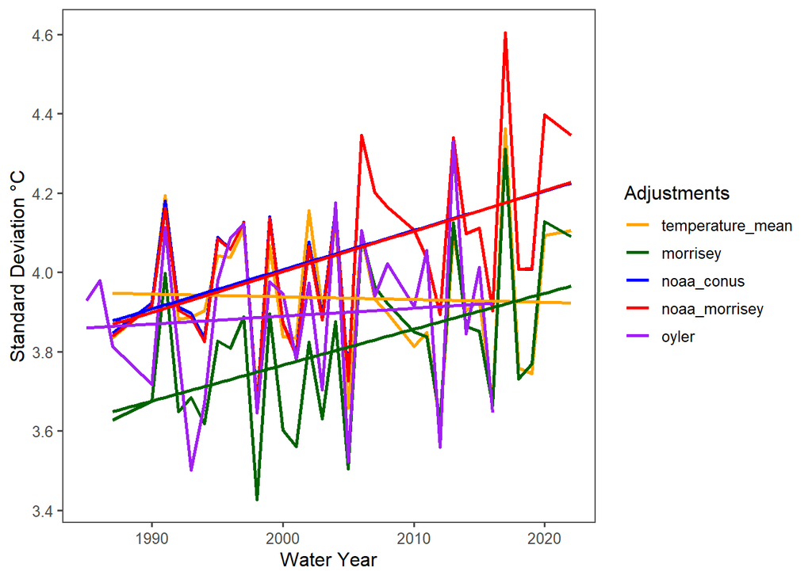

Standard deviation by correction.

```r
all_adjustments_Oyler <- all_adjustments %>%
  full_join(Oyler_SD, by= 'waterYear') %>%
  rename(oyler = sd_2) %>%
  left_join(Oyler_SD_NOAA_CONUS, by = "waterYear") %>%
  rename(oyler_noaa_conus = sd_2)

ggplot(all_adjustments_Oyler, aes(x=waterYear)) +
geom_line(aes(y = temperature_mean, color = "temperature_mean"), size =1)+
  geom_line(aes(y = morrisey, color = "morrisey"), size =1)+
  geom_line(aes(y = noaa_conus, color = "noaa_conus"), size =1)+
  geom_line(aes(y = noaa_morrisey, color= "noaa_morrisey"), size =1)+
  geom_line(aes(y = oyler, color= "oyler"), size =1)+
  #geom_line(aes(y = oyler_noaa_conus, color= "oyler_noaa_conus"), size =1)+
  geom_smooth(aes(x=waterYear, y = temperature_mean, color = "temperature_mean"), method=lm, se=FALSE)+
  geom_smooth(aes(x=waterYear, y = morrisey, color = "morrisey"), method=lm, se=FALSE)+
  geom_smooth(aes(x=waterYear, y = noaa_conus, color = "noaa_conus"), method=lm, se=FALSE)+
  geom_smooth(aes(x=waterYear, y = noaa_morrisey, color= "noaa_morrisey"), method=lm, se=FALSE)+
  geom_smooth(aes(x=waterYear, y = oyler, color= "oyler"), method=lm, se=FALSE)+
  #geom_smooth(aes(x=waterYear, y = oyler_noaa_conus, color= "oyler_noaa_conus"), method=lm, se=FALSE)+
  theme_few()+
  scale_colour_manual(name = "Adjustments", values=c("temperature_mean"="orange", "morrisey" = "darkgreen", "noaa_conus" ="blue", "noaa_morrisey" = "red", "oyler" = "purple"))+#, "oyler_noaa_conus" = "grey"))+
  xlab("Water Year")+
  ylab("Standard Deviation °C")
```

# Meeting 5/4/2023

As the Oyler data is interpolated/extrapolated, there is no point in applying the NOAA-CONUS correction. I’m commenting out the adjustment from the figures above.